# Statistics for Bioengineering - Week 2

Bill Cresko

# Week 2: EDA, Probability, and Experimental Design

## Week 2 Topics

- Exploratory data analysis
- Data visualization
- Parameters & statistics
- Probability distributions
- Estimates & confidence intervals

**Note**

**Readings:** Chapters 9-15

## Packages for This Week

- Install
- Load
- Interpretation

```r
# Install new packages (run once)
install.packages("nycflights13")
```

```r
# Load packages
library(tidyverse)    # ggplot2, dplyr, tidyr for data wrangling & visualization
library(nycflights13) # NYC flights data for dplyr examples
```

- `tidyverse` is a collection of packages for data science including ggplot2 (visualization), dplyr (data manipulation), and tidyr (data tidying)
- `nycflights13` provides the `flights` dataset with 336,776 flights departing NYC in 2013, used for practicing data wrangling

**Note**

**Dataset from package:** `flights` (336,776 flights departing NYC in 2013) - used for dplyr practice

# Exploratory Data Analysis

## What is EDA?

- First step in any data analysis
- Understand structure and patterns in your data
- Identify outliers, missing values, errors
- Generate hypotheses for formal testing

**Always visualize your data before running statistical tests!**

# Data Wrangling with Tidyverse

## Tidyverse Family of Packages

[figure not shown]

Figure 1: Tidyverse packages overview

- Output
- Code

Loading `tidyverse` attaches core packages: ggplot2, dplyr, tidyr, readr, purrr, tibble, stringr, and forcats.

```r
library(tidyverse)
```

Source: [tidyverse.org](https://www.tidyverse.org/)

## A tibble - a tidyverse dataframe

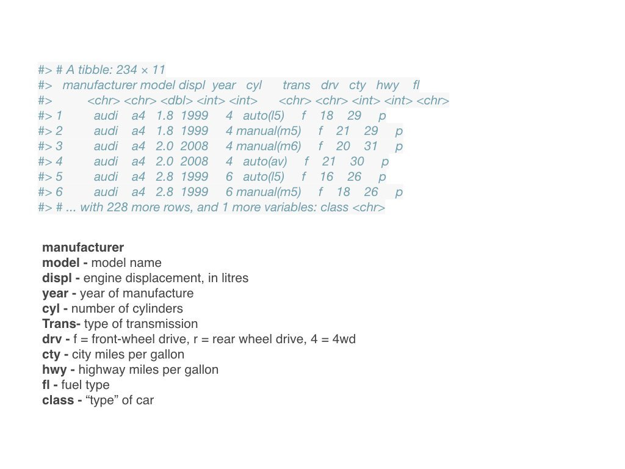

## DRAFT: A tibble - mpg dataset

- Output
- Variable definitions

```
# A tibble: 234 × 11
   manufacturer model      displ  year   cyl trans drv     cty   hwy fl    class
   <chr>        <chr>      <dbl> <int> <int> <chr> <chr> <int> <int> <chr> <chr>
 1 audi         a4           1.8  1999     4 auto… f        18    29 p     comp…
 2 audi         a4           1.8  1999     4 manu… f        21    29 p     comp…
 3 audi         a4           2    2008     4 manu… f        20    31 p     comp…
 4 audi         a4           2    2008     4 auto… f        21    30 p     comp…
 5 audi         a4           2.8  1999     6 auto… f        16    26 p     comp…
 6 audi         a4           2.8  1999     6 manu… f        18    26 p     comp…
 7 audi         a4           3.1  2008     6 auto… f        18    27 p     comp…
 8 audi         a4 quattro   1.8  1999     4 manu… 4        18    26 p     comp…
 9 audi         a4 quattro   1.8  1999     4 auto… 4        16    25 p     comp…
10 audi         a4 quattro   2    2008     4 manu… 4        20    28 p     comp…
# ℹ 224 more rows
```

| Variable | Description |
| --- | --- |
| `manufacturer` | Manufacturer name |
| `model` | Model name |
| `displ` | Engine displacement, in litres |
| `year` | Year of manufacture |
| `cyl` | Number of cylinders |
| `trans` | Type of transmission |
| `drv` | f = front-wheel, r = rear wheel, 4 = 4wd |
| `cty` | City miles per gallon |
| `hwy` | Highway miles per gallon |
| `fl` | Fuel type |
| `class` | “Type” of car |

## A tibble - a tidyverse dataframe

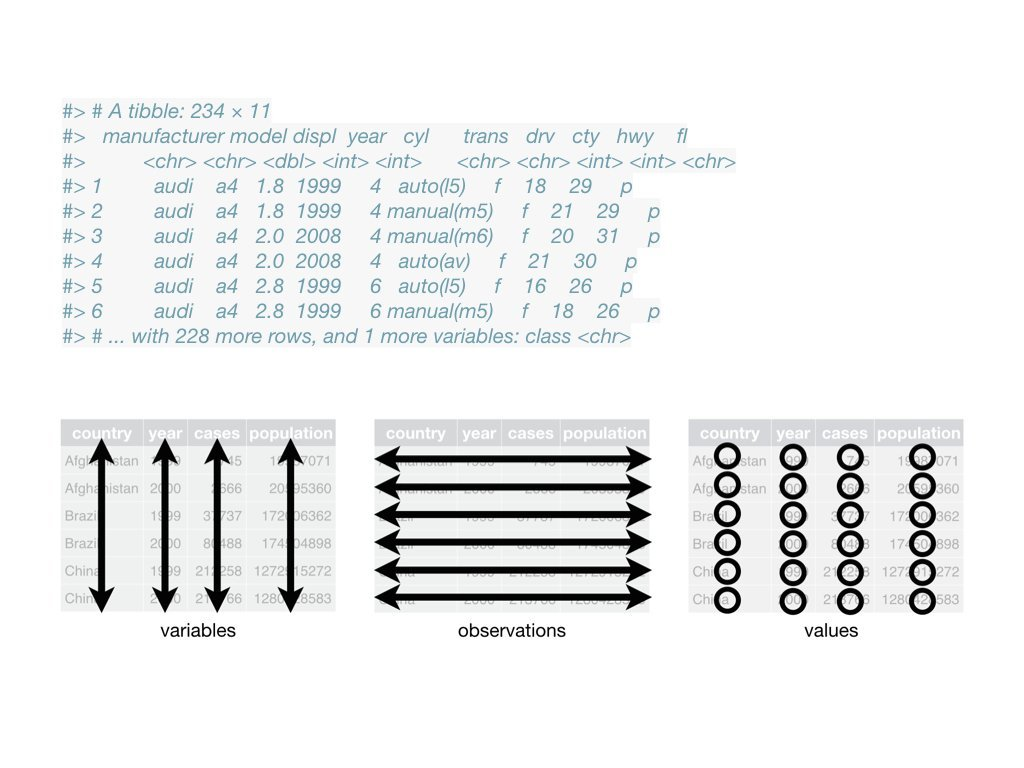

## Types of variables in a tibble

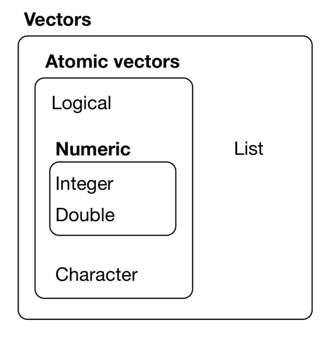

## Types of variables in a tibble (SVG)

[figure not shown]

R vector types hierarchy

## Key dplyr Verbs

- `dpylr` is a package in the `tidyverse` that gives you functions (aka verbs) to wrangle data.

| Verb | Purpose | Example |
| --- | --- | --- |
| `filter()` | Subset rows by values | `filter(df, x > 5)` |
| `select()` | Subset columns by name | `select(df, col1, col2)` |
| `arrange()` | Reorder rows | `arrange(df, x)` |
| `mutate()` | Create new columns | `mutate(df, z = x + y)` |
| `summarise()` | Collapse to summary | `summarise(df, mean = mean(x))` |

## Filter, Arrange, and Select

- Output
- Code
- Interpretation

```
# A tibble: 55,403 × 19
    year month   day dep_time sched_dep_time dep_delay arr_time sched_arr_time
   <int> <int> <int>    <int>          <int>     <dbl>    <int>          <int>
 1  2013    11     1        5           2359         6      352            345
 2  2013    11     1       35           2250       105      123           2356
 3  2013    11     1      455            500        -5      641            651
 4  2013    11     1      539            545        -6      856            827
 5  2013    11     1      542            545        -3      831            855
 6  2013    11     1      549            600       -11      912            923
 7  2013    11     1      550            600       -10      705            659
 8  2013    11     1      554            600        -6      659            701
 9  2013    11     1      554            600        -6      826            827
10  2013    11     1      554            600        -6      749            751
# ℹ 55,393 more rows
# ℹ 11 more variables: arr_delay <dbl>, carrier <chr>, flight <int>,
#   tailnum <chr>, origin <chr>, dest <chr>, air_time <dbl>, distance <dbl>,
#   hour <dbl>, minute <dbl>, time_hour <dttm>
```

```r
# Filter rows
filter(flights, month == 11 | month == 12)

# Arrange rows
arrange(flights, year, month, day)

# Select columns
select(flights, year, month, day)
```

- `filter()` subsets rows based on logical conditions; here selecting November and December flights using the OR operator
- `arrange()` reorders rows by one or more columns (ascending by default)
- `select()` picks specific columns, reducing the tibble to only the variables you need

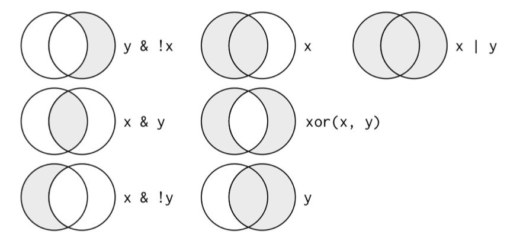

## Boolean Set Operations (SVG)

[figure not shown]

## Conditional Operators

| Operator | Meaning |
| --- | --- |
| `==` | Equals exactly |
| `<`, `<=` | Less than (or equal) |
| `>`, `>=` | Greater than (or equal) |
| `!=` | Not equal to |
| `!` | NOT operator |
| `&` | AND operator |
| `\|` | OR operator |
| `%in%` | Belongs to set |

## Mutate and Transmute

- Output
- Code
- Interpretation

[output not shown]

```r
# Add new columns based on existing ones
mutate(flights,
  gain = arr_delay - dep_delay,
  hours = air_time / 60,
  gain_per_hour = gain / hours
)

# Using pipes
flights |>
  mutate(
    gain = arr_delay - dep_delay,
    speed = distance / air_time * 60
  )
```

- `mutate()` adds new columns while keeping all existing columns, enabling derived variables like “gain” (difference between arrival and departure delay)
- The pipe operator `|>` chains operations together, reading left-to-right like a sentence
- New columns can reference other new columns created in the same `mutate()` call (e.g., `gain_per_hour` uses `gain` and `hours`)

## Group By and Summarise

- Output
- Code
- Interpretation

```
# A tibble: 365 × 4
# Groups:   year, month [12]
    year month   day delay
   <int> <int> <int> <dbl>
 1  2013     1     1 11.5
 2  2013     1     2 13.9
 3  2013     1     3 11.0
 4  2013     1     4  8.95
 5  2013     1     5  5.73
 6  2013     1     6  7.15
 7  2013     1     7  5.42
 8  2013     1     8  2.55
 9  2013     1     9  2.28
10  2013     1    10  2.84
# ℹ 355 more rows
```

```r
# Group by categorical variable
by_day <- group_by(flights, year, month, day)

# Summarise within groups
summarise(by_day, delay = mean(dep_delay, na.rm = TRUE))
```

- `group_by()` splits the data into groups defined by one or more categorical variables (here: year, month, day)
- `summarise()` then collapses each group into a single row with the computed summary statistic
- The `na.rm = TRUE` argument is essential because missing values would otherwise cause the mean to return NA for any group containing missing data

**Warning**

Aggregation functions return NA if any input value is NA. Use `na.rm = TRUE` to remove missing values.

## Other Useful dplyr Functions

| Function | Purpose |
| --- | --- |
| `slice()` | Subset rows by position |
| `pull()` | Extract column as vector |
| `count()` | Count observations |
| `distinct()` | Unique observations |

## R Exercise: Data Wrangling

**Exercise**

1. Read in `Week1b_Stickle_RNAseq.tsv` or `knee_injury.csv` dataset
2. `Select` a subset of categorical variables + quantitative variables
3. `Mutate` to create square root transformed versions
4. `Summarise` mean and SD `grouped by` categories (such as sex, population, treatment)
5. Write results to a `.csv` file

# Data Visualization with `ggplot2`

## Introduction to `ggplot2`

- Part of the `tidyverse` suite of packages
- GG stands for “Grammar of Graphics”
- Start with `ggplot()`, supply dataset and aesthetic mapping with `aes()`
- Add geometry layers with `geom_*()` functions

**Tip**

More info: https://ggplot2.tidyverse.org/

## Grammar of Graphics

[figure not shown]

Source: Leland Wilkinson, *The Grammar of Graphics*, 1999

## Scatterplots

- Output
- Code
- Interpretation

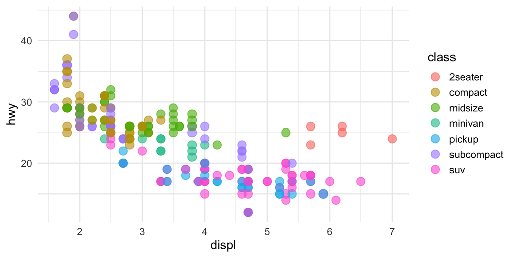

```r
ggplot(mpg, aes(displ, hwy, color = class)) +
  geom_point(size = 4, alpha = 0.6)
```

- The scatterplot reveals a negative relationship between engine displacement and highway fuel efficiency
- Color coding by vehicle class shows that compact and subcompact cars cluster at low displacement/high efficiency, while SUVs and pickups cluster at high displacement/low efficiency
- The alpha transparency helps reveal overlapping points and density patterns

## Boxplots

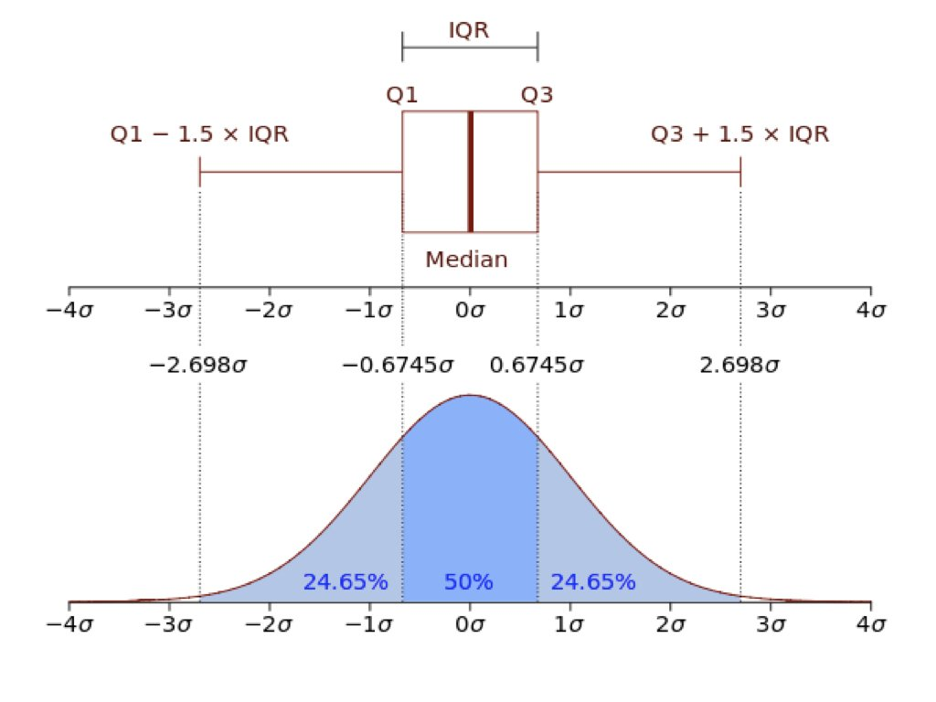

## Boxplots (SVG)

[figure not shown]

## DRAFT: Boxplot Anatomy with Normal Distribution

- Output
- Code
- Interpretation

[figure not shown]

```r
x <- seq(-4, 4, length.out = 1000)
y <- dnorm(x)
q1 <- qnorm(0.25)
q3 <- qnorm(0.75)
iqr <- q3 - q1

layout(matrix(c(1, 2), nrow = 2), heights = c(1, 2))

# Top: boxplot
boxplot(rnorm(10000), horizontal = TRUE, ylim = c(-4, 4),
        col = "white", border = "darkred", lwd = 2, axes = FALSE)

# Bottom: normal curve with shaded regions
plot(x, y, type = "n", axes = FALSE, xlab = "", ylab = "")
x_iqr <- x[x >= q1 & x <= q3]
polygon(c(q1, x_iqr, q3), c(0, dnorm(x_iqr), 0),
        col = rgb(0.4, 0.5, 0.8, 0.5), border = NA)
lines(x, y, lwd = 3, col = "darkred")
```

- The boxplot components map directly to regions of the normal distribution: the box spans Q1 to Q3 (the central 50% of data)
- Whiskers extend to Q1-1.5*IQR and Q3+1.5*IQR, capturing approximately 99.3% of normally distributed data
- Points beyond the whiskers are flagged as potential outliers, corresponding to values beyond approximately 2.7 standard deviations from the mean

## Boxplots

- Output
- Code
- Interpretation

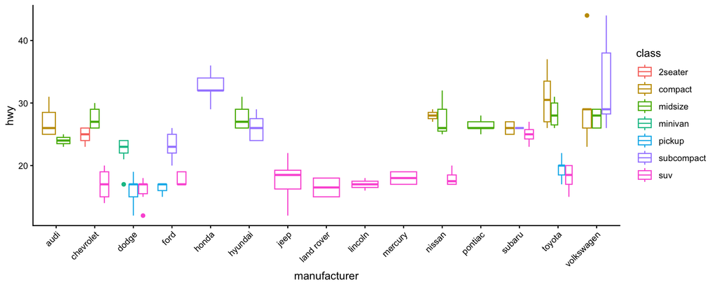

```r
ggplot(mpg, aes(manufacturer, hwy, colour = class)) +
  geom_boxplot() +
  theme_classic() +
  theme(axis.text.x = element_text(angle = 45, hjust=1))
```

- Boxplots summarize the distribution of highway MPG for each manufacturer, showing median, IQR, and outliers
- Color coding by vehicle class reveals that manufacturers producing multiple vehicle types show wider spreads in fuel efficiency
- The angled x-axis labels accommodate the many manufacturer names without overlap

## Common ggplot Geoms

| Geom | Purpose | Data Type |
| --- | --- | --- |
| `geom_point()` | Scatterplots | Two continuous |
| `geom_line()` | Line plots | Continuous over ordered |
| `geom_bar()` | Bar charts | Categorical counts |
| `geom_histogram()` | Histograms | Single continuous |
| `geom_boxplot()` | Boxplots | Continuous by category |
| `geom_smooth()` | Trend lines | Two continuous |

## Combining Geoms

- Output
- Code
- Interpretation

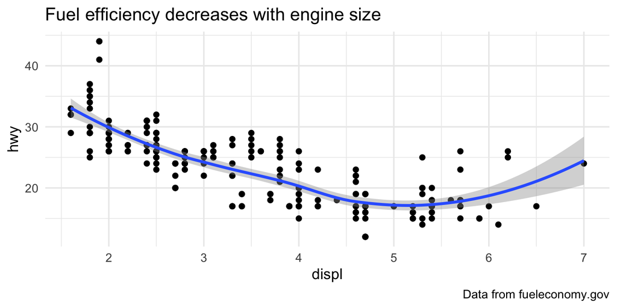

```r
ggplot(data=mpg, aes(x=displ, y=hwy)) +
  geom_point() +
  geom_smooth() +
  labs(title = "Fuel efficiency decreases with engine size",
       caption = "Data from fueleconomy.gov")
```

- Layering `geom_point()` and `geom_smooth()` shows both the raw data and the estimated trend simultaneously
- The smoothing curve with confidence band reveals a clear negative trend: larger engines consume more fuel
- The gray confidence band widens where data is sparse, honestly representing uncertainty in the trend estimate

## Faceting

- Output
- Code
- Interpretation

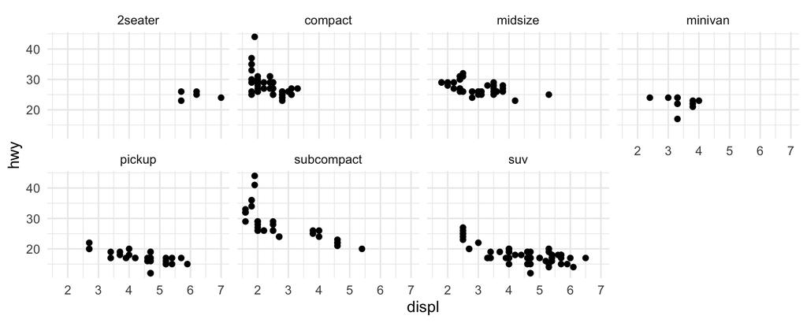

```r
ggplot(data=mpg) +
  geom_point(mapping=aes(x=displ, y=hwy)) +
  facet_wrap(~class, nrow=2)
```

- Faceting splits the data into separate panels by vehicle class, making within-group patterns easier to see
- Each panel shares the same axes, enabling direct visual comparison of the displacement-efficiency relationship across classes
- Some classes (e.g., 2seater) have few data points while others (e.g., SUV) are well-represented, which affects pattern reliability

## Three-Dimensional Data

- Output
- Code
- Interpretation

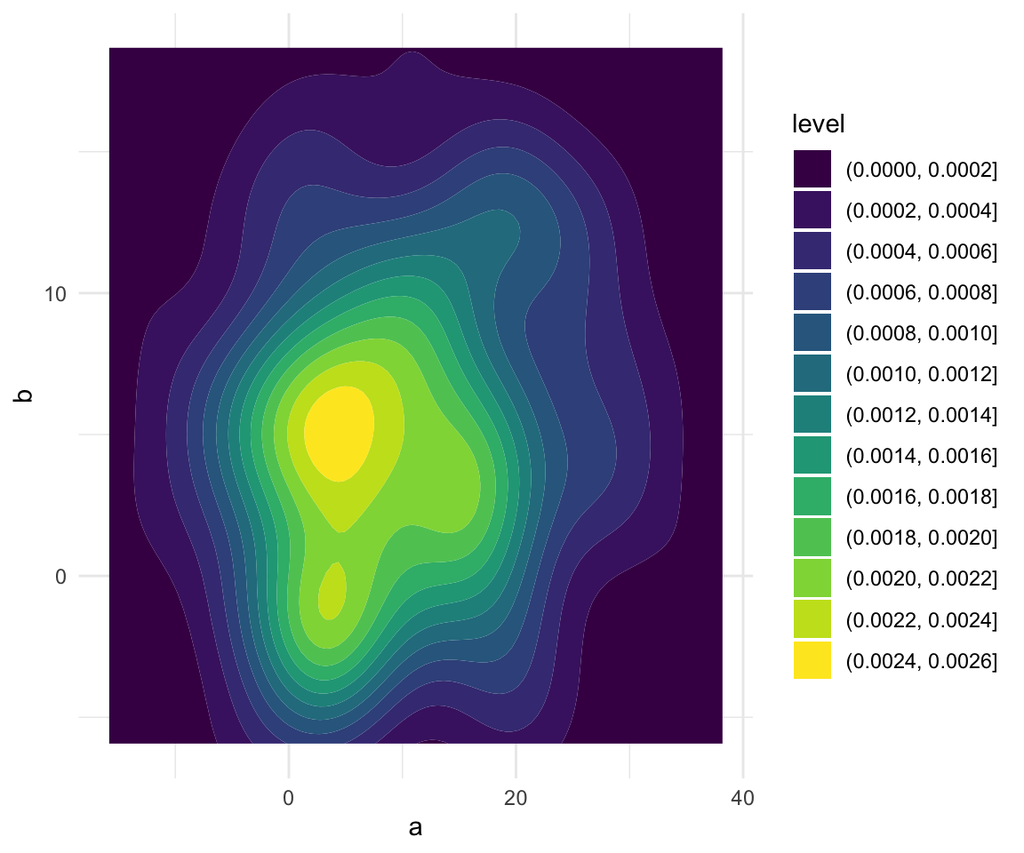

```r
set.seed(345)
d <- data.frame(a = rnorm(100, 10, 10), b = rnorm(100, 5, 5))
ggplot(d, aes(x=a, y=b)) +
  geom_density2d_filled() +
  theme_minimal()
```

- The filled 2D density plot represents a three-dimensional surface (x, y, density) projected onto two dimensions using color
- Warmer/brighter colors indicate regions of higher point density, revealing where observations cluster
- This is useful for visualizing bivariate distributions and identifying multimodal patterns that scatterplots alone might miss

## Choosing the Right Plot

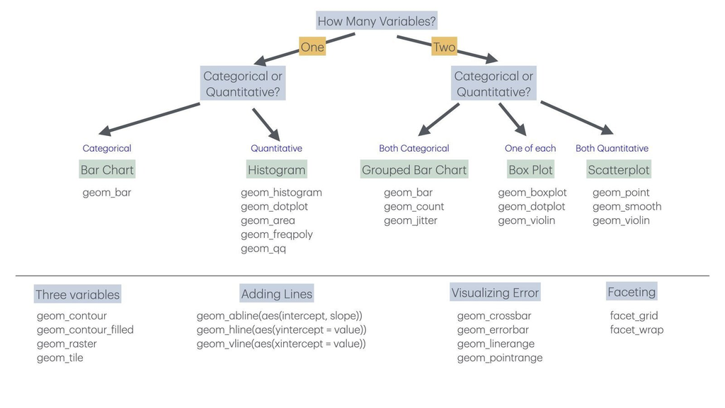

## Choosing the Right Plot (SVG)

[figure not shown]

## R Exercise: Data Visualization

**Exercise**

1. Read in `Week1b_Stickle_RNAseq.tsv` or `knee_injury.csv` dataset
2. Create `histograms` of data
3. Create histograms on a `faceted` figure for different levels of a category
4. Repeat steps 2 and 3 but create `boxplots`
5. Write plots to a `.pdf` file

# Best Practices in Data Visualization

## Good, Bad, and Ugly

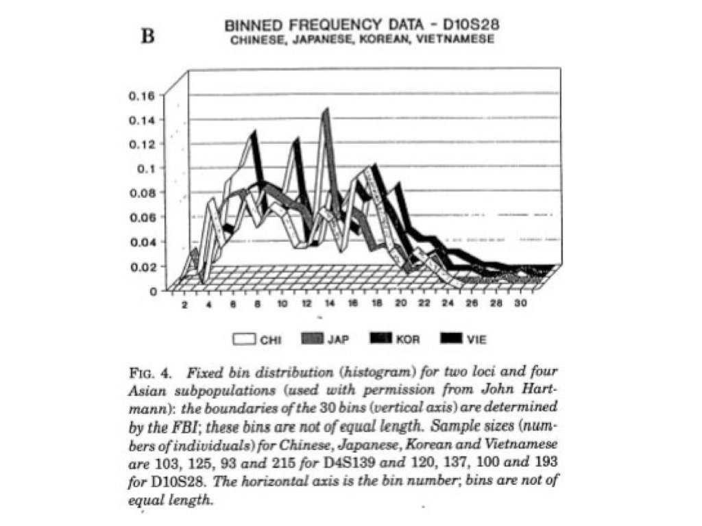

A ticker tape parade of confusion

## A line to no understanding

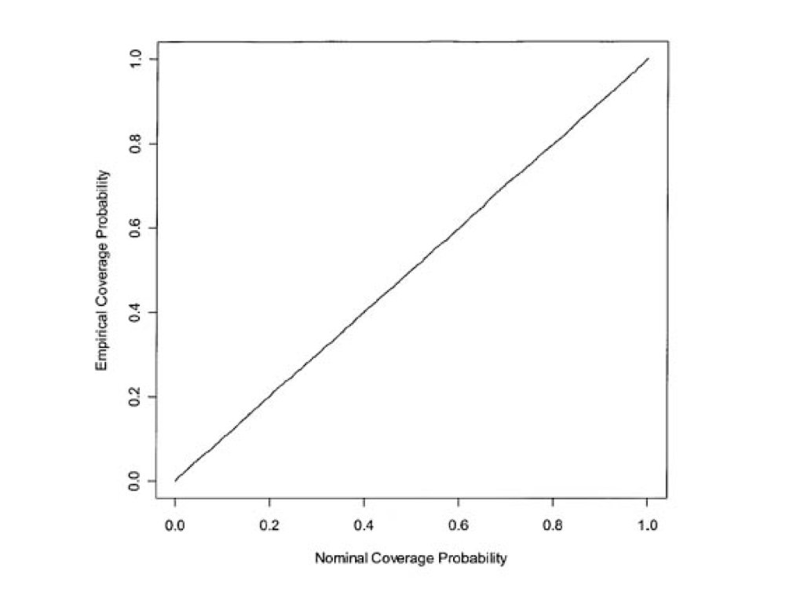

## Wack a mole

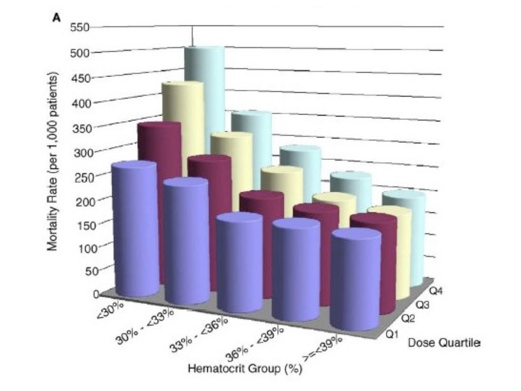

## Disk of disinformation

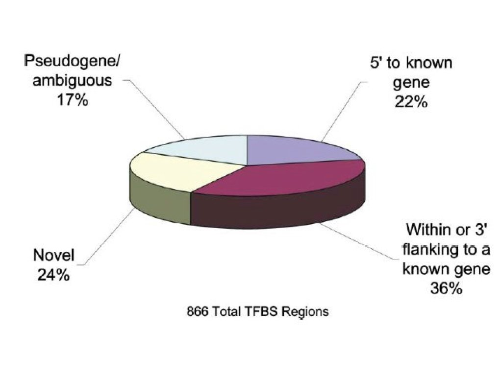

## Steaming pie chart mess

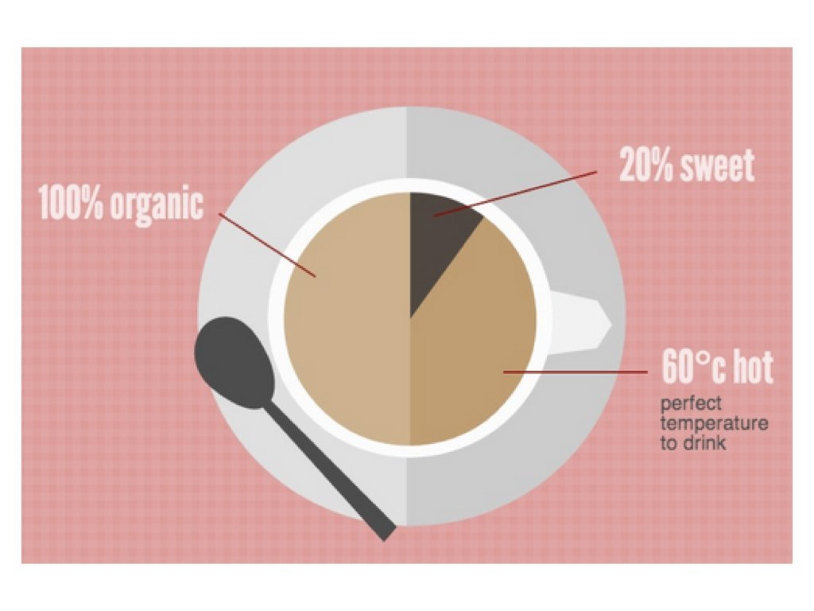

## A bake sale of pie charts

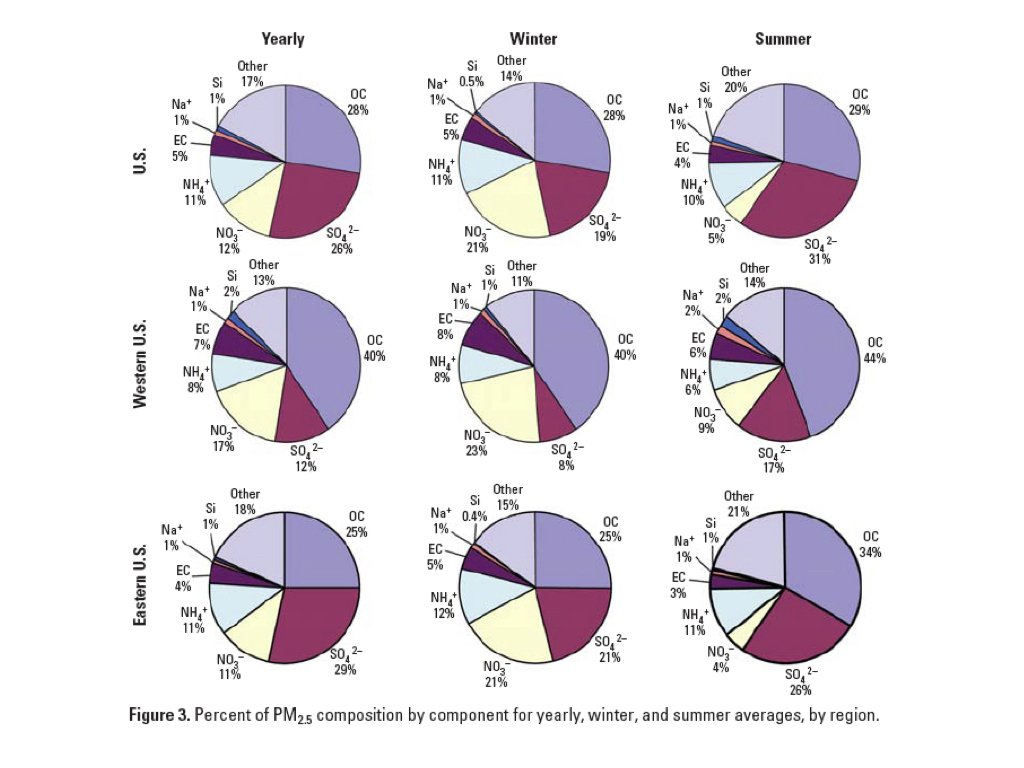

[figure not shown]

Minard’s map of Napoleon’s Russian campaign - Edward Tufte

Source: Charles Joseph Minard, 1869

[figure not shown]

Modern recreation of Minard-style data visualization

Source: FiveThirtyEight

## Principles of Effective Display

> “Graphical excellence is that which gives to the viewer the greatest number of ideas in the shortest time with the least ink in the smallest space”

> — Edward Tufte
- Show the data
- Encourage the eye to compare differences
- Represent magnitudes honestly and accurately
- Draw graphical elements clearly, minimizing clutter
- Make displays easy to interpret

## “Above All Else Show the Data”

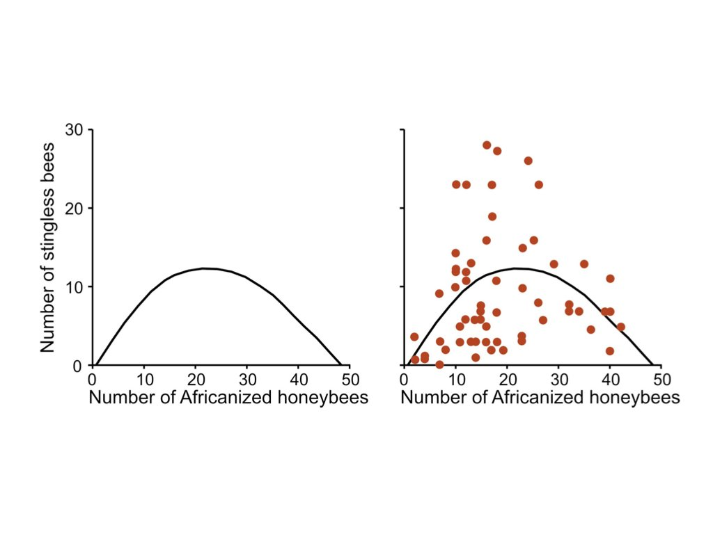

Source: Edward Tufte, *The Visual Display of Quantitative Information*, 1983

## “Maximize the Data to Ink Ratio”

[figure not shown]

The Economist 2006

Source: *The Economist*, 2006

## Represent Magnitudes Honestly

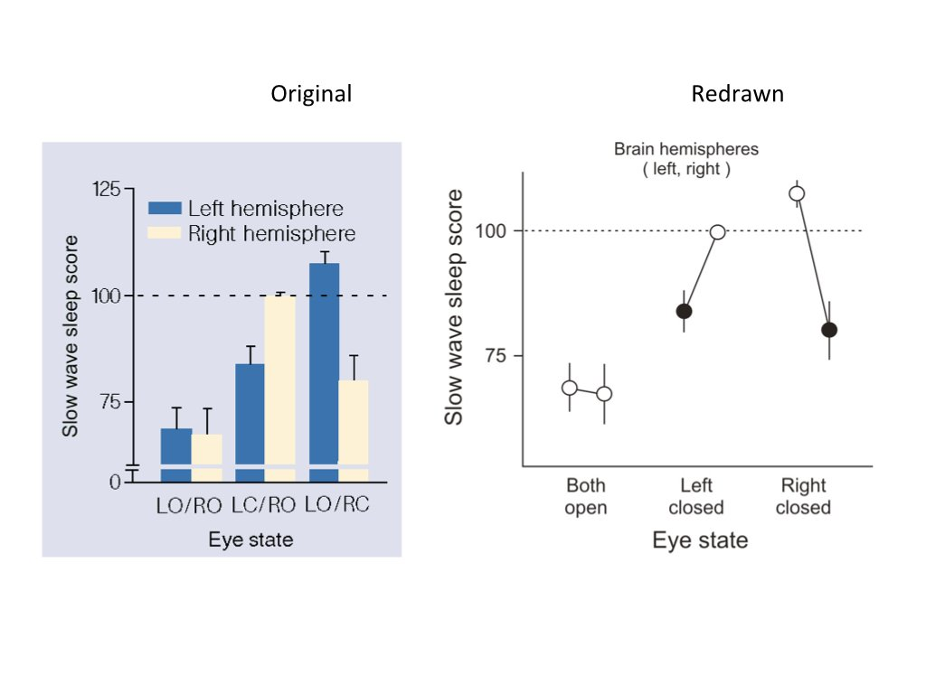

Rattenborg et al. 1999 Nature

Source: Rattenborg et al., *Nature*, 1999

## How NOT to Make a Figure

[figure not shown]

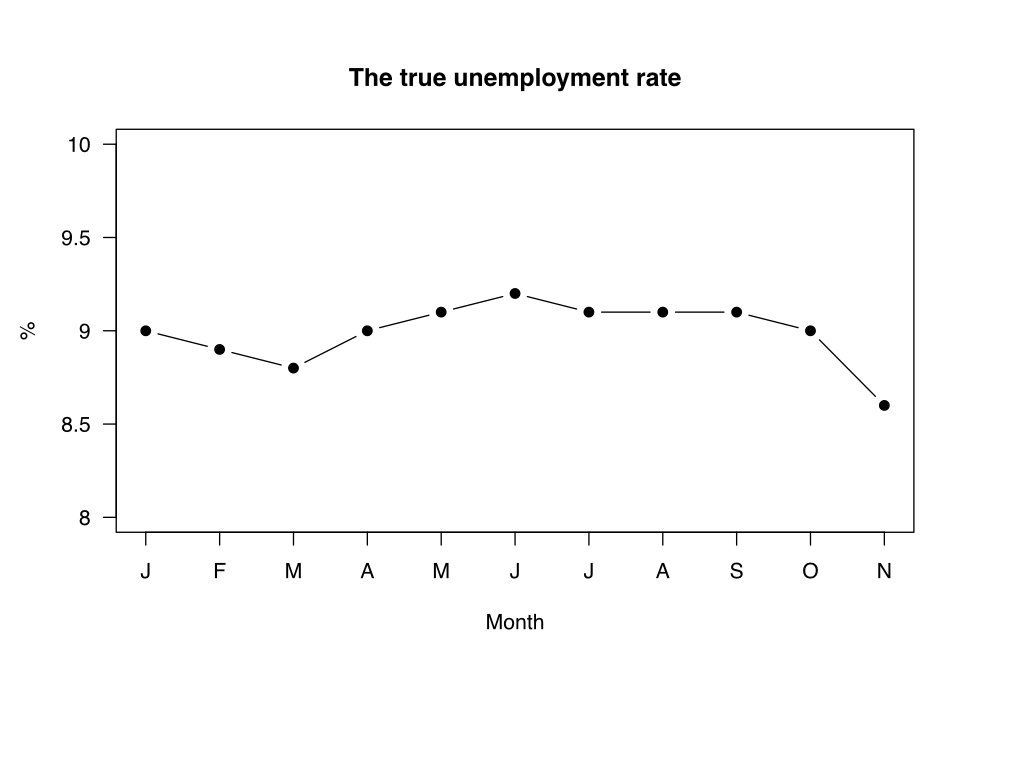

“Graphical excellence begins with telling the truth about the data” – Tufte 1983

Source: Fox News, 2011; Bureau of Labor Statistics data

# Parameters and Statistics

## Population vs. Sample

| Concept | Population | Sample |
| --- | --- | --- |
| Definition | All individuals | Subset of population |
| Parameters | μ (mean), σ (SD) | x̄ (mean), s (SD) |
| Goal | What we want to know | What we can measure |

**Important**

We use sample statistics to **estimate** population parameters

## Accuracy vs. Precision

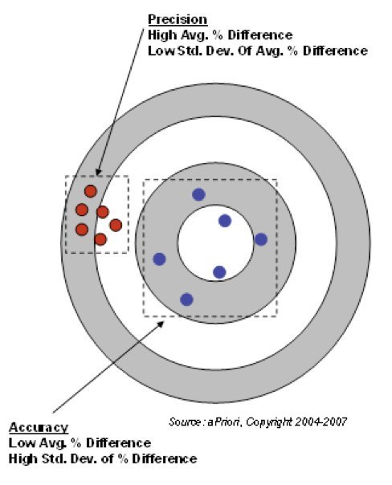

- **Accuracy**: closeness to true value
- **Precision**: closeness of repeated estimates to each other
- **Replication** quantifies variation
- **Randomization** avoids bias

Source: aPriori, Copyright 2004-2007

## Accuracy vs. Precision (SVG)

[figure not shown]

- **Accuracy**: closeness to true value
- **Precision**: closeness of repeated estimates to each other
- **Replication** quantifies variation
- **Randomization** avoids bias

## Stochastic Processes in Statistics

- We often want to know truths about the world, but can only estimate them
- Uncertainty in those estimates is a given
- Statistics is largely about quantifying and managing uncertainty
- Random variables are products of stochastic processes
- Expectations are based on theoretical probability distributions

## Two Interpretations of Probability

**Frequency interpretation:**

“Probabilities are mathematically convenient approximations to long run relative frequencies.”

**Subjective (Bayesian) interpretation:**

“A probability statement expresses the opinion of some individual regarding how certain an event is to occur.”

## Random Variables and Probability

- **Probability** is the expression of belief in some future outcome
- A **random variable** can take on different values with different probabilities
- The **sample space** is the universe of all possible values
- Sample space represented by:
  - **Probability mass distribution** (discrete)
  - **Probability density function** (continuous)

**Important**

Probabilities of a sample space **always sum to 1.0**

## Probability Rules

**‘And’ rule (multiplication):**

- Equation
- LaTeX
- Interpretation

$$Pr(X \text{ and } Y) = Pr(X) \times Pr(Y)$$

```
Pr(X \text{ and } Y) = Pr(X) \times Pr(Y)
```

- The multiplication rule states that the probability of both independent events occurring is the product of their individual probabilities
- This means joint events are always less probable than either event alone (since probabilities are between 0 and 1)

**‘Or’ rule (addition):**

- Equation
- LaTeX
- Interpretation

$$Pr(X \text{ or } Y) = Pr(X) + Pr(Y)$$

```
Pr(X \text{ or } Y) = Pr(X) + Pr(Y)
```

- The addition rule gives the probability that at least one of two mutually exclusive events occurs
- For non-mutually exclusive events, you must subtract the overlap: Pr(X or Y) = Pr(X) + Pr(Y) - Pr(X and Y)

**Note**

The ‘and’ rule assumes independent events. For non-independent events, we need conditional probabilities.

## Joint and Conditional Probability

**Joint probability (independent events):**

- Equation
- LaTeX
- Interpretation

$$Pr(X,Y) = Pr(X) \times Pr(Y)$$

```
Pr(X,Y) = Pr(X) \times Pr(Y)
```

- The joint probability of two independent events equals the product of their individual probabilities
- Independence means knowing that X occurred gives no information about whether Y will occur
- This simple multiplication rule only applies when events are truly independent; for dependent events, conditional probabilities are needed

**Conditional probability (independent):**

- Equation
- LaTeX
- Interpretation

$$Pr(Y|X) = Pr(Y) \text{ and } Pr(X|Y) = Pr(X)$$

```
Pr(Y|X) = Pr(Y) \text{ and } Pr(X|Y) = Pr(X)
```

- For independent events, conditioning on one event does not change the probability of the other
- This is the formal definition of statistical independence

**Conditional probability (non-independent):**

- Equation
- LaTeX
- Interpretation

$$Pr(Y|X) \neq Pr(Y) \text{ and } Pr(X|Y) \neq Pr(X)$$

```
Pr(Y|X) \neq Pr(Y) \text{ and } Pr(X|Y) \neq Pr(X)
```

- When events are dependent, knowing that one event occurred changes the probability of the other
- Most biological variables are not independent, which is why conditional probability is central to biostatistics

## Likelihood vs. Probability

- **Probability**: proportion of times an event would occur over many trials
- **Likelihood**: conditional probability of a parameter value given data
- Equation
- LaTeX
- Interpretation

$$L[\text{parameter}|\text{data}] = Pr[\text{data}|\text{parameter}]$$

```
L[\text{parameter}|\text{data}] = Pr[\text{data}|\text{parameter}]
```

- Likelihood reverses the direction of conditioning: instead of asking “given parameters, how likely is the data?”, it asks “given data, which parameters are most supported?”
- The likelihood function uses the same mathematical formula as the probability, but treats the parameter as the variable and the data as fixed
- Maximum likelihood estimation finds the parameter value that makes the observed data most probable
- **Maximum likelihood**: highest value of the likelihood function
- **Bayesian estimate**: uses prior distribution to update posterior distribution

## Moments of Distributions

**1st moment (mean/expectation):**

- Equation
- LaTeX
- Interpretation

$$E[X] = \sum_{\text{all x}}xP(X=x) = \mu$$

```
E[X] = \sum_{\text{all x}}xP(X=x) = \mu
```

- The expected value (mean) is a probability-weighted average of all possible outcomes
- It represents the “center of mass” of the distribution and the value you would expect on average over many observations
- For symmetric distributions the mean equals the median; for skewed distributions they differ

**2nd moment (variance):**

- Equation
- LaTeX
- Interpretation

$$Var(X) = E[(X-\mu)^2] = \sigma^2$$

```
Var(X) = E[(X-\mu)^2] = \sigma^2
```

- Variance measures the average squared deviation from the mean, quantifying how spread out the distribution is
- Because deviations are squared, larger deviations contribute disproportionately more to the variance
- Variance is in squared units of the original data, which is why we often take the square root to get standard deviation

**Standard deviation:**

- Equation
- LaTeX
- Interpretation

$$SD = \sqrt{\sigma^2} = \sigma$$

```
SD = \sqrt{\sigma^2} = \sigma
```

- The standard deviation is simply the square root of the variance, returning the spread measure to the original units of the data
- It quantifies the typical distance of individual observations from the mean

Higher moments include skewness (3rd) and kurtosis (4th).

# Discrete Probability Distributions

## PMF, PDF, and CDF in R

- Output
- Code
- Interpretation

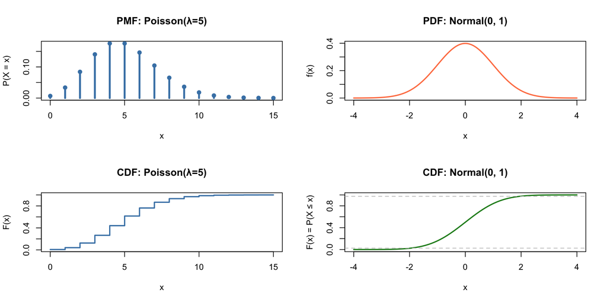

Figure 3: Comparing discrete (Poisson) and continuous (Normal) distributions (probability mass function, probability density function, and cumulative density function)

```r
par(mfrow = c(2, 2))

# Discrete (Poisson) PMF
x_disc <- 0:15
plot(x_disc, dpois(x_disc, lambda = 5), type = "h", lwd = 3, col = "steelblue",
     main = "PMF: Poisson(λ=5)", xlab = "x", ylab = "P(X = x)")
points(x_disc, dpois(x_disc, lambda = 5), pch = 19, col = "steelblue")

# Continuous (Normal) PDF
x_cont <- seq(-4, 4, length.out = 200)
plot(x_cont, dnorm(x_cont), type = "l", lwd = 2, col = "coral",
     main = "PDF: Normal(0, 1)", xlab = "x", ylab = "f(x)")

# Poisson CDF
plot(x_disc, ppois(x_disc, lambda = 5), type = "s", lwd = 2, col = "steelblue",
     main = "CDF: Poisson(λ=5)", xlab = "x", ylab = "F(x)")

# Normal CDF
plot(x_cont, pnorm(x_cont), type = "l", lwd = 2, col = "forestgreen",
     main = "CDF: Normal(0, 1)", xlab = "x", ylab = "F(x) = P(X ≤ x)")
abline(h = c(0.025, 0.975), lty = 2, col = "gray")
```

- The PMF (top-left) shows exact probabilities for each discrete outcome in a Poisson distribution; the PDF (top-right) shows probability density for continuous normal values
- The CDFs (bottom row) give cumulative probabilities P(X <= x), always increasing from 0 to 1
- The dashed lines on the normal CDF mark the 2.5% and 97.5% quantiles, which define the central 95% interval used in hypothesis testing

## Common moments of distributions

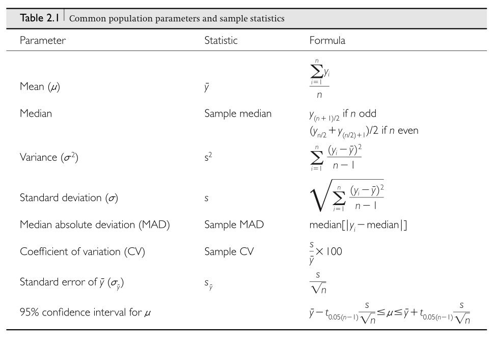

Source: Whitlock & Schluter, *The Analysis of Biological Data*, Table 2.1

## DRAFT: Common moments of distributions

**Table 2.1** Common population parameters and sample statistics

| Parameter | Statistic | Formula |
| --- | --- | --- |
| Mean ($\mu$) | $\bar{y}$ | $\frac{\sum_{i=1}^{n} y_i}{n}$ |
| Median | Sample median | $y_{(n+1)/2}$ if $n$ odd; $(y_{n/2} + y_{(n/2)+1})/2$ if $n$ even |
| Variance ($\sigma^2$) | $s^2$ | $\sum_{i=1}^{n} \frac{(y_i - \bar{y})^2}{n-1}$ |
| Standard deviation ($\sigma$) | $s$ | $\sqrt{\sum_{i=1}^{n} \frac{(y_i - \bar{y})^2}{n-1}}$ |
| Median absolute deviation (MAD) | Sample MAD | $\text{median}[\lvert y_i - \text{median} \rvert]$ |
| Coefficient of variation (CV) | Sample CV | $\frac{s}{\bar{y}} \times 100$ |
| Standard error of $\bar{y}$ ($\sigma_{\bar{y}}$) | $s_{\bar{y}}$ | $\frac{s}{\sqrt{n}}$ |
| 95% confidence interval for $\mu$ |  | $\bar{y} - t_{0.05(n-1)}\frac{s}{\sqrt{n}} \leq \mu \leq \bar{y} + t_{0.05(n-1)}\frac{s}{\sqrt{n}}$ |